# Quick Install

> `pip install netCDF4`

> `conda install -c conda-forge netCDF4`

`netcdf4-python` is a Python interface to the `netCDF C` library.

Network Common Data Form (NetCDF): files are

- self-describing (all documentation needed to work with data is included)
- hierarchical data (organized in groups and variables) format.
- Metadata and documentation of the data are included in the file itself
- is convenient to store huge data.
- The software is maintained by developers at `Unidata`, which is a subsidary of `UCAR`.
- There are currently several versions of NetCDF in use:
  - NETCDF3_CLASSIC: was the original netcdf binary format, and was limited to file sizes less than 2 Gb.
  - NETCDF3_64BIT_OFFSET: was introduced in version 3.6.0 of the library, and extended the original binary format to allow for file sizes greater than 2 Gb.
  - NETCDF3_64BIT_DATA: is a new format that requires version 4.4.0 of the C library. It extends the NETCDF3_64BIT_OFFSET binary format to allow for unsigned/64 bit integer data types.
  - NETCDF4_CLASSIC: use the version 4 disk format (HDF5), but omits features not found in the version 3 API. They can also be read by HDF5 clients.
  - netCDF classic: is the original format and the most commonly used version, but it can only store up 2 Gigabits of data.
  - netCDF-4: is the latest generation of NetCDF. It has the data storage capabilities netCDF 64-bit and can handle all netCDF versions.

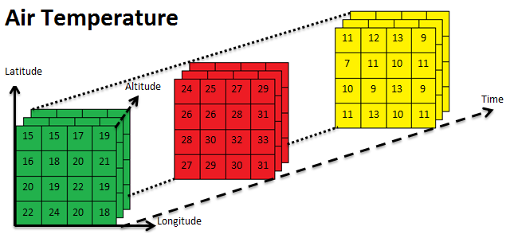

```python
from IPython import display
display.Image("/home/yoni/Documents/Python_Training_day1/03_day/md1.png")
```

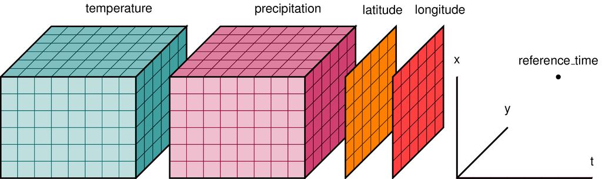

```python
display.Image("/home/yoni/Documents/Python_Training_day1/03_day/xarray.png")
```

A NetCDF4 file has three parts:

- variables and groups: main data product
- dimensions: dimension of the variables
- metadata: useful the information about variables.

# Imporing the netCDF4 library

```python
import netCDF4 as nc
```

## Import the nc file

```python
nc_file = '/home/yoni/Documents/Python_Training_day1/03_day/tamsat_2019_june.nc'
```

## Reading the `nc` file as a dataset

```python
ds = nc.Dataset(nc_file)
```

## Printing the dataset gives information

```python
print(ds)
```

```
<class 'netCDF4._netCDF4.Dataset'>
root group (NETCDF3_CLASSIC data model, file format NETCDF3):
    CDI: Climate Data Interface version 2.0.5 (https://mpimet.mpg.de/cdi)
    Conventions: CF-1.5
    institution: TAMSAT Research Group, Meteorology Department, University of Reading, UK
    title: TAMSAT Rain Fall Estimate (RFE)
    contact: tamsat@reading.ac.uk
    history: Sun Oct 02 19:59:08 2022: cdo enssum rfe2019_06-dk1.v3.nc rfe2019_06-dk2.v3.nc rfe2019_06-dk3.v3.nc tamsat_2019_june.nc
Processed from TIR archive using satop2 with max_gap[mins]=360
    latmin: 3.0
    latmax: 15.0
    lonmin: 33.0
    lonmax: 48.0
    latres: 0.0375
    lonres: 0.0375
    CDO: Climate Data Operators version 2.0.5 (https://mpimet.mpg.de/cdo)
    dimensions(sizes): time(1), lon(401), lat(321)
    variables(dimensions): int32 time(time), float64 lon(lon), float64 lat(lat), int16 rfe(time, lat, lon)
    groups:
```

## Metadata can be accessed by `Python dictionary`

```python
print(ds.__dict__)
```

[output not shown]

## Each metadata items can be acessed

```python
print(ds.__dict__['CDI'])
print(ds.__dict__['Conventions'])
print(ds.__dict__['title'])
print(ds.__dict__['contact'])
print(ds.__dict__['history'])
```

```
Climate Data Interface version 2.0.5 (https://mpimet.mpg.de/cdi)
CF-1.5
TAMSAT Rain Fall Estimate (RFE)
tamsat@reading.ac.uk
Sun Oct 02 19:59:08 2022: cdo enssum rfe2019_06-dk1.v3.nc rfe2019_06-dk2.v3.nc rfe2019_06-dk3.v3.nc tamsat_2019_june.nc
Processed from TIR archive using satop2 with max_gap[mins]=360
```

## Dimensional variables can be viwed as:

```python
for dim in ds.dimensions.values():
    print(dim)
```

```
<class 'netCDF4._netCDF4.Dimension'> (unlimited): name = 'time', size = 1
<class 'netCDF4._netCDF4.Dimension'>: name = 'lon', size = 401
<class 'netCDF4._netCDF4.Dimension'>: name = 'lat', size = 321
```

## Assessing individual dimensional variables

```python
ds.dimensions['lat']
```

```
<class 'netCDF4._netCDF4.Dimension'>: name = 'lat', size = 321
```

```python
ds.dimensions['lon']
```

```
<class 'netCDF4._netCDF4.Dimension'>: name = 'lon', size = 401
```

```python
ds.dimensions['time']
```

```
<class 'netCDF4._netCDF4.Dimension'> (unlimited): name = 'time', size = 1
```

## Each data variables can accessed as follow:

```python
for var in ds.variables.values():
    print(var)
```

```
<class 'netCDF4._netCDF4.Variable'>
int32 time(time)
    standard_name: time
    long_name: time
    units: days since 2019-06-01 0:0:0
    calendar: standard
    axis: T
unlimited dimensions: time
current shape = (1,)
filling on, default _FillValue of -2147483647 used
<class 'netCDF4._netCDF4.Variable'>
float64 lon(lon)
    standard_name: longitude
    long_name: longitude
    units: degrees_east
    axis: X
unlimited dimensions:
current shape = (401,)
filling on, default _FillValue of 9.969209968386869e+36 used
<class 'netCDF4._netCDF4.Variable'>
float64 lat(lat)
    standard_name: latitude
    long_name: latitude
    units: degrees_north
    axis: Y
unlimited dimensions:
current shape = (321,)
filling on, default _FillValue of 9.969209968386869e+36 used
<class 'netCDF4._netCDF4.Variable'>
int16 rfe(time, lat, lon)
    long_name: Rainfall Estimate
    units: mm
    _FillValue: -99
    missing_value: -99
    short_name: rfe
unlimited dimensions: time
current shape = (1, 321, 401)
filling on
```

## Access information for a specific variable

```python
print(ds['lon'])
```

```
<class 'netCDF4._netCDF4.Variable'>
float64 lon(lon)
    standard_name: longitude
    long_name: longitude
    units: degrees_east
    axis: X
unlimited dimensions:
current shape = (401,)
filling on, default _FillValue of 9.969209968386869e+36 used
```

```python
print(ds['lat'])
```

```
<class 'netCDF4._netCDF4.Variable'>
float64 lat(lat)
    standard_name: latitude
    long_name: latitude
    units: degrees_north
    axis: Y
unlimited dimensions:
current shape = (321,)
filling on, default _FillValue of 9.969209968386869e+36 used
```

```python
print(ds['time'])
```

```
<class 'netCDF4._netCDF4.Variable'>
int32 time(time)
    standard_name: time
    long_name: time
    units: days since 2019-06-01 0:0:0
    calendar: standard
    axis: T
unlimited dimensions: time
current shape = (1,)
filling on, default _FillValue of -2147483647 used
```

```python
print(ds['rfe'])
```

```
<class 'netCDF4._netCDF4.Variable'>
int16 rfe(time, lat, lon)
    long_name: Rainfall Estimate
    units: mm
    _FillValue: -99
    missing_value: -99
    short_name: rfe
unlimited dimensions: time
current shape = (1, 321, 401)
filling on
```

```python
print(ds.variables.keys())
```

[output not shown]

```python
print(ds.dimensions.keys())
```

[output not shown]

## Retrieving data from the dataset by array indexing

```python
lat = ds.variables['lat'][:]
lat.shape
```

```
(321,)
```

```python
lat
```

```
masked_array(data=[15.    , 14.9625, 14.925 , 14.8875, 14.85  , 14.8125,
                   14.775 , 14.7375, 14.7   , 14.6625, 14.625 , 14.5875,
                   14.55  , 14.5125, 14.475 , 14.4375, 14.4   , 14.3625,
                   14.325 , 14.2875, 14.25  , 14.2125, 14.175 , 14.1375,
                   14.1   , 14.0625, 14.025 , 13.9875, 13.95  , 13.9125,
                   13.875 , 13.8375, 13.8   , 13.7625, 13.725 , 13.6875,
                   13.65  , 13.6125, 13.575 , 13.5375, 13.5   , 13.4625,
                   13.425 , 13.3875, 13.35  , 13.3125, 13.275 , 13.2375,
                   13.2   , 13.1625, 13.125 , 13.0875, 13.05  , 13.0125,
                   12.975 , 12.9375, 12.9   , 12.8625, 12.825 , 12.7875,
                   12.75  , 12.7125, 12.675 , 12.6375, 12.6   , 12.5625,
                   12.525 , 12.4875, 12.45  , 12.4125, 12.375 , 12.3375,
                   12.3   , 12.2625, 12.225 , 12.1875, 12.15  , 12.1125,
                   12.075 , 12.0375, 12.    , 11.9625, 11.925 , 11.8875,
                   11.85  , 11.8125, 11.775 , 11.7375, 11.7   , 11.6625,
                   11.625 , 11.5875, 11.55  , 11.5125, 11.475 , 11.4375,
                   11.4   , 11.3625, 11.325 , 11.2875, 11.25  , 11.2125,
                   11.175 , 11.1375, 11.1   , 11.0625, 11.025 , 10.9875,
                   10.95  , 10.9125, 10.875 , 10.8375, 10.8   , 10.7625,
                   10.725 , 10.6875, 10.65  , 10.6125, 10.575 , 10.5375,
                   10.5   , 10.4625, 10.425 , 10.3875, 10.35  , 10.3125,
                   10.275 , 10.2375, 10.2   , 10.1625, 10.125 , 10.0875,
                   10.05  , 10.0125,  9.975 ,  9.9375,  9.9   ,  9.8625,
                    9.825 ,  9.7875,  9.75  ,  9.7125,  9.675 ,  9.6375,
                    9.6   ,  9.5625,  9.525 ,  9.4875,  9.45  ,  9.4125,
                    9.375 ,  9.3375,  9.3   ,  9.2625,  9.225 ,  9.1875,
                    9.15  ,  9.1125,  9.075 ,  9.0375,  9.    ,  8.9625,
                    8.925 ,  8.8875,  8.85  ,  8.8125,  8.775 ,  8.7375,
                    8.7   ,  8.6625,  8.625 ,  8.5875,  8.55  ,  8.5125,
                    8.475 ,  8.4375,  8.4   ,  8.3625,  8.325 ,  8.2875,
                    8.25  ,  8.2125,  8.175 ,  8.1375,  8.1   ,  8.0625,
                    8.025 ,  7.9875,  7.95  ,  7.9125,  7.875 ,  7.8375,
                    7.8   ,  7.7625,  7.725 ,  7.6875,  7.65  ,  7.6125,
                    7.575 ,  7.5375,  7.5   ,  7.4625,  7.425 ,  7.3875,
                    7.35  ,  7.3125,  7.275 ,  7.2375,  7.2   ,  7.1625,
                    7.125 ,  7.0875,  7.05  ,  7.0125,  6.975 ,  6.9375,
                    6.9   ,  6.8625,  6.825 ,  6.7875,  6.75  ,  6.7125,
                    6.675 ,  6.6375,  6.6   ,  6.5625,  6.525 ,  6.4875,
                    6.45  ,  6.4125,  6.375 ,  6.3375,  6.3   ,  6.2625,
                    6.225 ,  6.1875,  6.15  ,  6.1125,  6.075 ,  6.0375,
                    6.    ,  5.9625,  5.925 ,  5.8875,  5.85  ,  5.8125,
                    5.775 ,  5.7375,  5.7   ,  5.6625,  5.625 ,  5.5875,
                    5.55  ,  5.5125,  5.475 ,  5.4375,  5.4   ,  5.3625,
                    5.325 ,  5.2875,  5.25  ,  5.2125,  5.175 ,  5.1375,
                    5.1   ,  5.0625,  5.025 ,  4.9875,  4.95  ,  4.9125,
                    4.875 ,  4.8375,  4.8   ,  4.7625,  4.725 ,  4.6875,
                    4.65  ,  4.6125,  4.575 ,  4.5375,  4.5   ,  4.4625,
                    4.425 ,  4.3875,  4.35  ,  4.3125,  4.275 ,  4.2375,
                    4.2   ,  4.1625,  4.125 ,  4.0875,  4.05  ,  4.0125,
                    3.975 ,  3.9375,  3.9   ,  3.8625,  3.825 ,  3.7875,
                    3.75  ,  3.7125,  3.675 ,  3.6375,  3.6   ,  3.5625,
                    3.525 ,  3.4875,  3.45  ,  3.4125,  3.375 ,  3.3375,
                    3.3   ,  3.2625,  3.225 ,  3.1875,  3.15  ,  3.1125,
                    3.075 ,  3.0375,  3.    ],
             mask=False,
       fill_value=1e+20)
```

```python
lat_data = lat.data
```

```python
lat_data
```

```
array([15.    , 14.9625, 14.925 , 14.8875, 14.85  , 14.8125, 14.775 ,
       14.7375, 14.7   , 14.6625, 14.625 , 14.5875, 14.55  , 14.5125,
       14.475 , 14.4375, 14.4   , 14.3625, 14.325 , 14.2875, 14.25  ,
       14.2125, 14.175 , 14.1375, 14.1   , 14.0625, 14.025 , 13.9875,
       13.95  , 13.9125, 13.875 , 13.8375, 13.8   , 13.7625, 13.725 ,
       13.6875, 13.65  , 13.6125, 13.575 , 13.5375, 13.5   , 13.4625,
       13.425 , 13.3875, 13.35  , 13.3125, 13.275 , 13.2375, 13.2   ,
       13.1625, 13.125 , 13.0875, 13.05  , 13.0125, 12.975 , 12.9375,
       12.9   , 12.8625, 12.825 , 12.7875, 12.75  , 12.7125, 12.675 ,
       12.6375, 12.6   , 12.5625, 12.525 , 12.4875, 12.45  , 12.4125,
       12.375 , 12.3375, 12.3   , 12.2625, 12.225 , 12.1875, 12.15  ,
       12.1125, 12.075 , 12.0375, 12.    , 11.9625, 11.925 , 11.8875,
       11.85  , 11.8125, 11.775 , 11.7375, 11.7   , 11.6625, 11.625 ,
       11.5875, 11.55  , 11.5125, 11.475 , 11.4375, 11.4   , 11.3625,
       11.325 , 11.2875, 11.25  , 11.2125, 11.175 , 11.1375, 11.1   ,
       11.0625, 11.025 , 10.9875, 10.95  , 10.9125, 10.875 , 10.8375,
       10.8   , 10.7625, 10.725 , 10.6875, 10.65  , 10.6125, 10.575 ,
       10.5375, 10.5   , 10.4625, 10.425 , 10.3875, 10.35  , 10.3125,
       10.275 , 10.2375, 10.2   , 10.1625, 10.125 , 10.0875, 10.05  ,
       10.0125,  9.975 ,  9.9375,  9.9   ,  9.8625,  9.825 ,  9.7875,
        9.75  ,  9.7125,  9.675 ,  9.6375,  9.6   ,  9.5625,  9.525 ,
        9.4875,  9.45  ,  9.4125,  9.375 ,  9.3375,  9.3   ,  9.2625,
        9.225 ,  9.1875,  9.15  ,  9.1125,  9.075 ,  9.0375,  9.    ,
        8.9625,  8.925 ,  8.8875,  8.85  ,  8.8125,  8.775 ,  8.7375,
        8.7   ,  8.6625,  8.625 ,  8.5875,  8.55  ,  8.5125,  8.475 ,
        8.4375,  8.4   ,  8.3625,  8.325 ,  8.2875,  8.25  ,  8.2125,
        8.175 ,  8.1375,  8.1   ,  8.0625,  8.025 ,  7.9875,  7.95  ,
        7.9125,  7.875 ,  7.8375,  7.8   ,  7.7625,  7.725 ,  7.6875,
        7.65  ,  7.6125,  7.575 ,  7.5375,  7.5   ,  7.4625,  7.425 ,
        7.3875,  7.35  ,  7.3125,  7.275 ,  7.2375,  7.2   ,  7.1625,
        7.125 ,  7.0875,  7.05  ,  7.0125,  6.975 ,  6.9375,  6.9   ,
        6.8625,  6.825 ,  6.7875,  6.75  ,  6.7125,  6.675 ,  6.6375,
        6.6   ,  6.5625,  6.525 ,  6.4875,  6.45  ,  6.4125,  6.375 ,
        6.3375,  6.3   ,  6.2625,  6.225 ,  6.1875,  6.15  ,  6.1125,
        6.075 ,  6.0375,  6.    ,  5.9625,  5.925 ,  5.8875,  5.85  ,
        5.8125,  5.775 ,  5.7375,  5.7   ,  5.6625,  5.625 ,  5.5875,
        5.55  ,  5.5125,  5.475 ,  5.4375,  5.4   ,  5.3625,  5.325 ,
        5.2875,  5.25  ,  5.2125,  5.175 ,  5.1375,  5.1   ,  5.0625,
        5.025 ,  4.9875,  4.95  ,  4.9125,  4.875 ,  4.8375,  4.8   ,
        4.7625,  4.725 ,  4.6875,  4.65  ,  4.6125,  4.575 ,  4.5375,
        4.5   ,  4.4625,  4.425 ,  4.3875,  4.35  ,  4.3125,  4.275 ,
        4.2375,  4.2   ,  4.1625,  4.125 ,  4.0875,  4.05  ,  4.0125,
        3.975 ,  3.9375,  3.9   ,  3.8625,  3.825 ,  3.7875,  3.75  ,
        3.7125,  3.675 ,  3.6375,  3.6   ,  3.5625,  3.525 ,  3.4875,
        3.45  ,  3.4125,  3.375 ,  3.3375,  3.3   ,  3.2625,  3.225 ,
        3.1875,  3.15  ,  3.1125,  3.075 ,  3.0375,  3.    ])
```

```python
lon = ds.variables['lon'][:]
lon.shape
```

```
(401,)
```

```python
lon
```

```
masked_array(data=[33.    , 33.0375, 33.075 , 33.1125, 33.15  , 33.1875,
                   33.225 , 33.2625, 33.3   , 33.3375, 33.375 , 33.4125,
                   33.45  , 33.4875, 33.525 , 33.5625, 33.6   , 33.6375,
                   33.675 , 33.7125, 33.75  , 33.7875, 33.825 , 33.8625,
                   33.9   , 33.9375, 33.975 , 34.0125, 34.05  , 34.0875,
                   34.125 , 34.1625, 34.2   , 34.2375, 34.275 , 34.3125,
                   34.35  , 34.3875, 34.425 , 34.4625, 34.5   , 34.5375,
                   34.575 , 34.6125, 34.65  , 34.6875, 34.725 , 34.7625,
                   34.8   , 34.8375, 34.875 , 34.9125, 34.95  , 34.9875,
                   35.025 , 35.0625, 35.1   , 35.1375, 35.175 , 35.2125,
                   35.25  , 35.2875, 35.325 , 35.3625, 35.4   , 35.4375,
                   35.475 , 35.5125, 35.55  , 35.5875, 35.625 , 35.6625,
                   35.7   , 35.7375, 35.775 , 35.8125, 35.85  , 35.8875,
                   35.925 , 35.9625, 36.    , 36.0375, 36.075 , 36.1125,
                   36.15  , 36.1875, 36.225 , 36.2625, 36.3   , 36.3375,
                   36.375 , 36.4125, 36.45  , 36.4875, 36.525 , 36.5625,
                   36.6   , 36.6375, 36.675 , 36.7125, 36.75  , 36.7875,
                   36.825 , 36.8625, 36.9   , 36.9375, 36.975 , 37.0125,
                   37.05  , 37.0875, 37.125 , 37.1625, 37.2   , 37.2375,
                   37.275 , 37.3125, 37.35  , 37.3875, 37.425 , 37.4625,
                   37.5   , 37.5375, 37.575 , 37.6125, 37.65  , 37.6875,
                   37.725 , 37.7625, 37.8   , 37.8375, 37.875 , 37.9125,
                   37.95  , 37.9875, 38.025 , 38.0625, 38.1   , 38.1375,
                   38.175 , 38.2125, 38.25  , 38.2875, 38.325 , 38.3625,
                   38.4   , 38.4375, 38.475 , 38.5125, 38.55  , 38.5875,
                   38.625 , 38.6625, 38.7   , 38.7375, 38.775 , 38.8125,
                   38.85  , 38.8875, 38.925 , 38.9625, 39.    , 39.0375,
                   39.075 , 39.1125, 39.15  , 39.1875, 39.225 , 39.2625,
                   39.3   , 39.3375, 39.375 , 39.4125, 39.45  , 39.4875,
                   39.525 , 39.5625, 39.6   , 39.6375, 39.675 , 39.7125,
                   39.75  , 39.7875, 39.825 , 39.8625, 39.9   , 39.9375,
                   39.975 , 40.0125, 40.05  , 40.0875, 40.125 , 40.1625,
                   40.2   , 40.2375, 40.275 , 40.3125, 40.35  , 40.3875,
                   40.425 , 40.4625, 40.5   , 40.5375, 40.575 , 40.6125,
                   40.65  , 40.6875, 40.725 , 40.7625, 40.8   , 40.8375,
                   40.875 , 40.9125, 40.95  , 40.9875, 41.025 , 41.0625,
                   41.1   , 41.1375, 41.175 , 41.2125, 41.25  , 41.2875,
                   41.325 , 41.3625, 41.4   , 41.4375, 41.475 , 41.5125,
                   41.55  , 41.5875, 41.625 , 41.6625, 41.7   , 41.7375,
                   41.775 , 41.8125, 41.85  , 41.8875, 41.925 , 41.9625,
```

[output cut: 14 more lines]

```
                   45.15  , 45.1875, 45.225 , 45.2625, 45.3   , 45.3375,
                   45.375 , 45.4125, 45.45  , 45.4875, 45.525 , 45.5625,
                   45.6   , 45.6375, 45.675 , 45.7125, 45.75  , 45.7875,
                   45.825 , 45.8625, 45.9   , 45.9375, 45.975 , 46.0125,
                   46.05  , 46.0875, 46.125 , 46.1625, 46.2   , 46.2375,
                   46.275 , 46.3125, 46.35  , 46.3875, 46.425 , 46.4625,
                   46.5   , 46.5375, 46.575 , 46.6125, 46.65  , 46.6875,
                   46.725 , 46.7625, 46.8   , 46.8375, 46.875 , 46.9125,
                   46.95  , 46.9875, 47.025 , 47.0625, 47.1   , 47.1375,
                   47.175 , 47.2125, 47.25  , 47.2875, 47.325 , 47.3625,
                   47.4   , 47.4375, 47.475 , 47.5125, 47.55  , 47.5875,
                   47.625 , 47.6625, 47.7   , 47.7375, 47.775 , 47.8125,
                   47.85  , 47.8875, 47.925 , 47.9625, 48.    ],
             mask=False,
       fill_value=1e+20)
```

```python
lon_data = lon.data
lon_data
```

```
array([33.    , 33.0375, 33.075 , 33.1125, 33.15  , 33.1875, 33.225 ,
       33.2625, 33.3   , 33.3375, 33.375 , 33.4125, 33.45  , 33.4875,
       33.525 , 33.5625, 33.6   , 33.6375, 33.675 , 33.7125, 33.75  ,
       33.7875, 33.825 , 33.8625, 33.9   , 33.9375, 33.975 , 34.0125,
       34.05  , 34.0875, 34.125 , 34.1625, 34.2   , 34.2375, 34.275 ,
       34.3125, 34.35  , 34.3875, 34.425 , 34.4625, 34.5   , 34.5375,
       34.575 , 34.6125, 34.65  , 34.6875, 34.725 , 34.7625, 34.8   ,
       34.8375, 34.875 , 34.9125, 34.95  , 34.9875, 35.025 , 35.0625,
       35.1   , 35.1375, 35.175 , 35.2125, 35.25  , 35.2875, 35.325 ,
       35.3625, 35.4   , 35.4375, 35.475 , 35.5125, 35.55  , 35.5875,
       35.625 , 35.6625, 35.7   , 35.7375, 35.775 , 35.8125, 35.85  ,
       35.8875, 35.925 , 35.9625, 36.    , 36.0375, 36.075 , 36.1125,
       36.15  , 36.1875, 36.225 , 36.2625, 36.3   , 36.3375, 36.375 ,
       36.4125, 36.45  , 36.4875, 36.525 , 36.5625, 36.6   , 36.6375,
       36.675 , 36.7125, 36.75  , 36.7875, 36.825 , 36.8625, 36.9   ,
       36.9375, 36.975 , 37.0125, 37.05  , 37.0875, 37.125 , 37.1625,
       37.2   , 37.2375, 37.275 , 37.3125, 37.35  , 37.3875, 37.425 ,
       37.4625, 37.5   , 37.5375, 37.575 , 37.6125, 37.65  , 37.6875,
       37.725 , 37.7625, 37.8   , 37.8375, 37.875 , 37.9125, 37.95  ,
       37.9875, 38.025 , 38.0625, 38.1   , 38.1375, 38.175 , 38.2125,
       38.25  , 38.2875, 38.325 , 38.3625, 38.4   , 38.4375, 38.475 ,
       38.5125, 38.55  , 38.5875, 38.625 , 38.6625, 38.7   , 38.7375,
       38.775 , 38.8125, 38.85  , 38.8875, 38.925 , 38.9625, 39.    ,
       39.0375, 39.075 , 39.1125, 39.15  , 39.1875, 39.225 , 39.2625,
       39.3   , 39.3375, 39.375 , 39.4125, 39.45  , 39.4875, 39.525 ,
       39.5625, 39.6   , 39.6375, 39.675 , 39.7125, 39.75  , 39.7875,
       39.825 , 39.8625, 39.9   , 39.9375, 39.975 , 40.0125, 40.05  ,
       40.0875, 40.125 , 40.1625, 40.2   , 40.2375, 40.275 , 40.3125,
       40.35  , 40.3875, 40.425 , 40.4625, 40.5   , 40.5375, 40.575 ,
       40.6125, 40.65  , 40.6875, 40.725 , 40.7625, 40.8   , 40.8375,
       40.875 , 40.9125, 40.95  , 40.9875, 41.025 , 41.0625, 41.1   ,
       41.1375, 41.175 , 41.2125, 41.25  , 41.2875, 41.325 , 41.3625,
       41.4   , 41.4375, 41.475 , 41.5125, 41.55  , 41.5875, 41.625 ,
       41.6625, 41.7   , 41.7375, 41.775 , 41.8125, 41.85  , 41.8875,
       41.925 , 41.9625, 42.    , 42.0375, 42.075 , 42.1125, 42.15  ,
       42.1875, 42.225 , 42.2625, 42.3   , 42.3375, 42.375 , 42.4125,
       42.45  , 42.4875, 42.525 , 42.5625, 42.6   , 42.6375, 42.675 ,
       42.7125, 42.75  , 42.7875, 42.825 , 42.8625, 42.9   , 42.9375,
       42.975 , 43.0125, 43.05  , 43.0875, 43.125 , 43.1625, 43.2   ,
       43.2375, 43.275 , 43.3125, 43.35  , 43.3875, 43.425 , 43.4625,
       43.5   , 43.5375, 43.575 , 43.6125, 43.65  , 43.6875, 43.725 ,
       43.7625, 43.8   , 43.8375, 43.875 , 43.9125, 43.95  , 43.9875,
       44.025 , 44.0625, 44.1   , 44.1375, 44.175 , 44.2125, 44.25  ,
       44.2875, 44.325 , 44.3625, 44.4   , 44.4375, 44.475 , 44.5125,
       44.55  , 44.5875, 44.625 , 44.6625, 44.7   , 44.7375, 44.775 ,
       44.8125, 44.85  , 44.8875, 44.925 , 44.9625, 45.    , 45.0375,
       45.075 , 45.1125, 45.15  , 45.1875, 45.225 , 45.2625, 45.3   ,
       45.3375, 45.375 , 45.4125, 45.45  , 45.4875, 45.525 , 45.5625,
       45.6   , 45.6375, 45.675 , 45.7125, 45.75  , 45.7875, 45.825 ,
       45.8625, 45.9   , 45.9375, 45.975 , 46.0125, 46.05  , 46.0875,
       46.125 , 46.1625, 46.2   , 46.2375, 46.275 , 46.3125, 46.35  ,
       46.3875, 46.425 , 46.4625, 46.5   , 46.5375, 46.575 , 46.6125,
       46.65  , 46.6875, 46.725 , 46.7625, 46.8   , 46.8375, 46.875 ,
       46.9125, 46.95  , 46.9875, 47.025 , 47.0625, 47.1   , 47.1375,
       47.175 , 47.2125, 47.25  , 47.2875, 47.325 , 47.3625, 47.4   ,
       47.4375, 47.475 , 47.5125, 47.55  , 47.5875, 47.625 , 47.6625,
       47.7   , 47.7375, 47.775 , 47.8125, 47.85  , 47.8875, 47.925 ,
       47.9625, 48.    ])
```

```python
time = ds.variables['time'][:]
time.shape
```

```
(1,)
```

```python
rainfall = ds.variables['rfe'][:]
#rainfall1 = ds['rfe'][:]
rainfall.shape
```

```
(1, 321, 401)
```

```python
rainfall
```

```
masked_array(
  data=[[[37, 31, 25, ..., 9, 8, 8],
         [34, 28, 23, ..., 7, 8, 8],
         [28, 27, 28, ..., 9, 10, 8],
         ...,
         [237, 236, 227, ..., --, --, --],
         [225, 225, 217, ..., --, --, --],
         [216, 217, 207, ..., --, --, --]]],
  mask=[[[False, False, False, ..., False, False, False],
         [False, False, False, ..., False, False, False],
         [False, False, False, ..., False, False, False],
         ...,
         [False, False, False, ...,  True,  True,  True],
         [False, False, False, ...,  True,  True,  True],
         [False, False, False, ...,  True,  True,  True]]],
  fill_value=-99,
  dtype=int16)
```

```python
rinfall_data = rainfall.data
rinfall_data.shape
```

```
(1, 321, 401)
```

```python
rinfall_data
```

```
array([[[ 37,  31,  25, ...,   9,   8,   8],
        [ 34,  28,  23, ...,   7,   8,   8],
        [ 28,  27,  28, ...,   9,  10,   8],
        ...,
        [237, 236, 227, ..., -99, -99, -99],
        [225, 225, 217, ..., -99, -99, -99],
        [216, 217, 207, ..., -99, -99, -99]]], dtype=int16)
```

```python
rinfall_data.shape
```

```
(1, 321, 401)
```

### Remove the dimensions

```python
Rainfall_only = rinfall_data[0, :, :]
Rainfall_only.shape
```

```
(321, 401)
```

## Export to Excel, CSV Formats

```python
import numpy as np
import pandas as pd
```

```python
df = pd.DataFrame(Rainfall_only)
```

```python
df.shape
```

```
(321, 401)
```

```python
print(type(df))
```

```
<class 'pandas.core.frame.DataFrame'>
```

```python
df
```

|  | 0 | 1 | 2 | 3 | 4 | 5 | 6 | 7 | 8 | 9 | ... | 391 | 392 | 393 | 394 | 395 | 396 | 397 | 398 | 399 | 400 |
| --- | --- | --- | --- | --- | --- | --- | --- | --- | --- | --- | --- | --- | --- | --- | --- | --- | --- | --- | --- | --- | --- |
| 0 | 37 | 31 | 25 | 25 | 25 | 27 | 30 | 32 | 33 | 33 | ... | 13 | 13 | 12 | 12 | 9 | 9 | 7 | 9 | 8 | 8 |
| 1 | 34 | 28 | 23 | 23 | 24 | 26 | 28 | 31 | 33 | 35 | ... | 14 | 13 | 12 | 12 | 11 | 10 | 10 | 7 | 8 | 8 |
| 2 | 28 | 27 | 28 | 29 | 29 | 29 | 31 | 32 | 36 | 38 | ... | 12 | 13 | 12 | 12 | 10 | 10 | 9 | 9 | 10 | 8 |
| 3 | 27 | 29 | 30 | 31 | 33 | 31 | 34 | 34 | 35 | 37 | ... | 14 | 14 | 11 | 12 | 12 | 12 | 11 | 10 | 10 | 11 |
| 4 | 25 | 26 | 29 | 34 | 36 | 36 | 37 | 38 | 36 | 37 | ... | 14 | 13 | 13 | 13 | 11 | 11 | 12 | 10 | 11 | 11 |
| ... | ... | ... | ... | ... | ... | ... | ... | ... | ... | ... | ... | ... | ... | ... | ... | ... | ... | ... | ... | ... | ... |
| 316 | 259 | 257 | 237 | 244 | 237 | 238 | 229 | 213 | 212 | 219 | ... | -99 | -99 | -99 | -99 | -99 | -99 | -99 | -99 | -99 | -99 |
| 317 | 248 | 242 | 237 | 243 | 237 | 238 | 241 | 233 | 228 | 234 | ... | -99 | -99 | -99 | -99 | -99 | -99 | -99 | -99 | -99 | -99 |
| 318 | 237 | 236 | 227 | 237 | 244 | 234 | 223 | 224 | 220 | 224 | ... | -99 | -99 | -99 | -99 | -99 | -99 | -99 | -99 | -99 | -99 |
| 319 | 225 | 225 | 217 | 231 | 216 | 210 | 207 | 210 | 219 | 213 | ... | -99 | -99 | -99 | -99 | -99 | -99 | -99 | -99 | -99 | -99 |
| 320 | 216 | 217 | 207 | 215 | 204 | 205 | 209 | 209 | 207 | 218 | ... | -99 | -99 | -99 | -99 | -99 | -99 | -99 | -99 | -99 | -99 |

321 rows × 401 columns

```python
df.to_excel("rainfall.xlsx")
```

```python
df.to_csv("rainfall.csv")
```

## Functions

### ncdump

```python
file_name = nc_file
```

```python
def my_ncdump(file_name):
    with nc.Dataset(file_name, mode='r') as ncfid:
         for name, var in ncfid.variables.items():
             print("{}:".format(name))
             print("{:>20}: {}".format("Dimension", var.dimensions))
             print("{:>20}: {}".format("Dimension value", var.shape))
             print("{:>20}: {}".format("Type", var.dtype))
             for attr in var.ncattrs():
                 print("{:>20}: {}".format(attr, var.getncattr(attr)))
         print()
         print("Global attributes")
         for attr in ncfid.ncattrs():
             print("{:>20}: {}".format(attr, ncfid.getncattr(attr)))

my_ncdump(file_name)
```

```
time:
           Dimension: ('time',)
     Dimension value: (1,)
                Type: int32
       standard_name: time
           long_name: time
               units: days since 2019-06-01 0:0:0
            calendar: standard
                axis: T
lon:
           Dimension: ('lon',)
     Dimension value: (401,)
                Type: float64
       standard_name: longitude
           long_name: longitude
               units: degrees_east
                axis: X
lat:
           Dimension: ('lat',)
     Dimension value: (321,)
                Type: float64
       standard_name: latitude
           long_name: latitude
               units: degrees_north
                axis: Y
rfe:
           Dimension: ('time', 'lat', 'lon')
     Dimension value: (1, 321, 401)
                Type: int16
           long_name: Rainfall Estimate
               units: mm
          _FillValue: -99
       missing_value: -99
          short_name: rfe

Global attributes
                 CDI: Climate Data Interface version 2.0.5 (https://mpimet.mpg.de/cdi)
         Conventions: CF-1.5
         institution: TAMSAT Research Group, Meteorology Department, University of Reading, UK
               title: TAMSAT Rain Fall Estimate (RFE)
             contact: tamsat@reading.ac.uk
             history: Sun Oct 02 19:59:08 2022: cdo enssum rfe2019_06-dk1.v3.nc rfe2019_06-dk2.v3.nc rfe2019_06-dk3.v3.nc tamsat_2019_june.nc
Processed from TIR archive using satop2 with max_gap[mins]=360
              latmin: 3.0
              latmax: 15.0
              lonmin: 33.0
              lonmax: 48.0
              latres: 0.0375
              lonres: 0.0375
                 CDO: Climate Data Operators version 2.0.5 (https://mpimet.mpg.de/cdo)
```

## Close the dataset

```python
ds.close()
```

## Write a netCDF Dataset with Python (netCDF4)

```python
# open a netCDF file to write
ncout = nc.Dataset('testout.nc', 'w', format='NETCDF4')
```

```python
ncout
```

```
<class 'netCDF4._netCDF4.Dataset'>
root group (NETCDF4 data model, file format HDF5):
    dimensions(sizes):
    variables(dimensions):
    groups:
```

### Creating dimensions

- `createDimension` method is used to create dimensions.
- Every dimension has a name and a length.
- Setting the dimension length to 0 or None makes it unlimited, so it can grow.
- For NETCDF4 files, any variable's dimension can be unlimited.
- For NETCDF4_CLASSIC and NETCDF3* files, only one per variable can be unlimited, and it must be the leftmost (slowest varying) dimension.

```python
lat_dim = ncout.createDimension('lat', 73)     # latitude axis
lon_dim = ncout.createDimension('lon', 144)    # longitude axis
time_dim = ncout.createDimension('time', None) # unlimited axis (can be appended to).
```

```python
for dim in ncout.dimensions.items():
    print(dim)
```

```
('lat', <class 'netCDF4._netCDF4.Dimension'>: name = 'lat', size = 73)
('lon', <class 'netCDF4._netCDF4.Dimension'>: name = 'lon', size = 144)
('time', <class 'netCDF4._netCDF4.Dimension'> (unlimited): name = 'time', size = 0)
```

### Creating Attributes

- netCDF attributes can be created just like you would for any python object.
- Best to adhere to established conventions (like the CF conventions)
- http://cfconventions.org/Data/cf-conventions/cf-conventions-1.10/cf-conventions.html

```python
ncout.title='My model data'
print(ncout.title)
```

```
My model data
```

```python
ncout.subtitle="My model data subtitle"
print(ncout.subtitle)
```

```
My model data subtitle
```

```python
print(ncout)
```

```
<class 'netCDF4._netCDF4.Dataset'>
root group (NETCDF4 data model, file format HDF5):
    title: My model data
    subtitle: My model data subtitle
    dimensions(sizes): lat(73), lon(144), time(0)
    variables(dimensions):
    groups:
```

### Creating Variables

- A variable has a `name`, a `type`, a `shape`, and `data values`.
- The shape of a variable is specified by a tuple of dimension names.
- A variable should also have some named attributes, such as 'units', that describe the data.
- The createVariable method takes 3 mandatory args.
  - the 1st argument is the variable name (a string). This is used as the key to access the variable object from the variables dictionary.
  - the 2nd argument is the datatype (most numpy datatypes supported).
  - the third argument is a tuple containing the dimension names
  - the dimensions must be created first

```python
lat = ncout.createVariable('lat', np.float32, ('lat',))
lat.units = 'degrees_north'
lat.long_name = 'latitude'
```

```python
lat
```

```
<class 'netCDF4._netCDF4.Variable'>
float32 lat(lat)
    units: degrees_north
    long_name: latitude
unlimited dimensions:
current shape = (73,)
filling on, default _FillValue of 9.969209968386869e+36 used
```

```python
lon = ncout.createVariable('lon', np.float32, ('lon',))
lon.units = 'degrees_east'
lon.long_name = 'longitude'
```

```python
lon
```

```
<class 'netCDF4._netCDF4.Variable'>
float32 lon(lon)
    units: degrees_east
    long_name: longitude
unlimited dimensions:
current shape = (144,)
filling on, default _FillValue of 9.969209968386869e+36 used
```

```python
time = ncout.createVariable('time', np.float64, ('time',))
time.units = 'hours since 1800-01-01'
time.long_name = 'time'
```

```python
time
```

```
<class 'netCDF4._netCDF4.Variable'>
float64 time(time)
    units: hours since 1800-01-01
    long_name: time
unlimited dimensions: time
current shape = (0,)
filling on, default _FillValue of 9.969209968386869e+36 used
```

```python
# Define a 3D variable to hold the data
temp = ncout.createVariable('temp',np.float64,('time','lat','lon')) # note: unlimited dimension is leftmost
temp.units = 'K' # degrees Kelvin
temp.standard_name = 'air_temperature' # this is a CF standard name
```

```python
temp
```

```
<class 'netCDF4._netCDF4.Variable'>
float64 temp(time, lat, lon)
    units: K
    standard_name: air_temperature
unlimited dimensions: time
current shape = (0, 73, 144)
filling on, default _FillValue of 9.969209968386869e+36 used
```

```python
print("-- Some pre-defined attributes for variable temp:")
print("temp.dimensions:", temp.dimensions)
print("temp.shape:", temp.shape)
print("temp.dtype:", temp.dtype)
print("temp.ndim:", temp.ndim)
```

```
-- Some pre-defined attributes for variable temp:
temp.dimensions: ('time', 'lat', 'lon')
temp.shape: (0, 73, 144)
temp.dtype: float64
temp.ndim: 3
```

### Writing data

```python
nlats = len(lat_dim);
nlons = len(lon_dim);
ntimes = 3
```

```python
nlats
```

```
73
```

```python
nlons
```

```
144
```

```python
ntimes
```

```
3
```

```python
lat[:] = -90. + (180./nlats)*np.arange(nlats) # south pole to north pole
```

```python
lat
```

```
<class 'netCDF4._netCDF4.Variable'>
float32 lat(lat)
    units: degrees_north
    long_name: latitude
unlimited dimensions:
current shape = (73,)
filling on, default _FillValue of 9.969209968386869e+36 used
```

```python
lon[:] = (180./nlats)*np.arange(nlons) # Greenwich meridian eastward
```

```python
# create a 3D array of random numbers
data_arr = np.random.uniform(low=280,high=330,size=(ntimes,nlats,nlons))
data_arr.shape
```

```
(3, 73, 144)
```

```python
# Write the data.
temp[:,:,:] = data_arr  # Appends data along unlimited dimension
```

```python
temp.shape
```

```
(3, 73, 144)
```

```python
temp[:,:,:].min()
```

```
280.00078869694994
```

```python
temp[:,:,:].max()
```

```
329.9996010064103
```

### Appends the 4th time slice

```python
# create a 2D array of random numbers
data_slice = np.random.uniform(low=280,high=330,size=(nlats,nlons))
temp[3,:,:] = data_slice
```

```python
temp.shape
```

```
(4, 73, 144)
```

```python
print(time)
```

```
<class 'netCDF4._netCDF4.Variable'>
float64 time(time)
    units: hours since 1800-01-01
    long_name: time
unlimited dimensions: time
current shape = (4,)
filling on, default _FillValue of 9.969209968386869e+36 used
```

### Let's add the time variable

```python
times_arr = time[:]
```

```python
times_arr
```

```
masked_array(data=[--, --, --, --],
             mask=[ True,  True,  True,  True],
       fill_value=9.969209968386869e+36,
            dtype=float64)
```

```python
print(type(times_arr),times_arr)  # das
```

```
<class 'numpy.ma.core.MaskedArray'> [-- -- -- --]
```

```python
import datetime as dt
from netCDF4 import date2num,num2date
```

```python
# 1st 4 days of October.
dates = [dt.datetime(2014,10,1,0),dt.datetime(2014,10,2,0),dt.datetime(2014,10,3,0),dt.datetime(2014,10,4,0)]
```

```python
print(dates)
```

```
[datetime.datetime(2014, 10, 1, 0, 0), datetime.datetime(2014, 10, 2, 0, 0), datetime.datetime(2014, 10, 3, 0, 0), datetime.datetime(2014, 10, 4, 0, 0)]
```

```python
times = date2num(dates, time.units)
print(times, time.units) # numeric values
```

```
[1882440 1882464 1882488 1882512] hours since 1800-01-01
```

```python
time[:] = times
```

```python
print(time[:])
```

```
[1882440. 1882464. 1882488. 1882512.]
```

```python
print(time.units)
```

```
hours since 1800-01-01
```

```python
print(num2date(time[:],time.units))
```

```
[cftime.DatetimeGregorian(2014, 10, 1, 0, 0, 0, 0, has_year_zero=False)
 cftime.DatetimeGregorian(2014, 10, 2, 0, 0, 0, 0, has_year_zero=False)
 cftime.DatetimeGregorian(2014, 10, 3, 0, 0, 0, 0, has_year_zero=False)
 cftime.DatetimeGregorian(2014, 10, 4, 0, 0, 0, 0, has_year_zero=False)]
```

```python
print(ncout)
```

```
<class 'netCDF4._netCDF4.Dataset'>
root group (NETCDF4 data model, file format HDF5):
    title: My model data
    subtitle: My model data subtitle
    dimensions(sizes): lat(73), lon(144), time(4)
    variables(dimensions): float32 lat(lat), float32 lon(lon), float64 time(time), float64 temp(time, lat, lon)
    groups:
```

```python
# close the Dataset.
ncout.close(); print('Dataset is closed!')
```

```
Dataset is closed!
```

```python
!ncdump -h /home/yoni/Documents/Python_Training_day1/02_day/testout.nc
```

```
netcdf testout {
dimensions:
	lat = 73 ;
	lon = 144 ;
	time = UNLIMITED ; // (4 currently)
variables:
	float lat(lat) ;
		lat:units = "degrees_north" ;
		lat:long_name = "latitude" ;
	float lon(lon) ;
		lon:units = "degrees_east" ;
		lon:long_name = "longitude" ;
	double time(time) ;
		time:units = "hours since 1800-01-01" ;
		time:long_name = "time" ;
	double temp(time, lat, lon) ;
		temp:units = "K" ;
		temp:standard_name = "air_temperature" ;

// global attributes:
		:title = "My model data" ;
		:subtitle = "My model data subtitle" ;
}
```